# Data Wrangling (Data Preprocessing)

## **Scan II**

```r
par(mfrow = c(2, 2))
merged_data$income.to.tuition.cost.ratio %>%
  boxplot(main = "Box Plot of income to tuition ratio",
          ylab = "ratio")

merged_data$`Avg tuition (USD)` %>%
  boxplot(main = "Box Plot of averge tuition cost",
          ylab = "tuition cost(USD)")
```

```r
merged_data$Income.Median.Houseold.Income%>%
  boxplot(main = "Box Plot of Median household incomes",
          ylab = "$USD")

merged_data$Education.Bachelor.s.Degree.or.Higher %>%
  boxplot(main = "Box Plot %bachelors degree",
          ylab = "% of the population")
```

[figure not shown]

```r
par(mfrow = c(1, 1))
```

```r
NA
NA
```

```r
par(mfrow = c(2, 2))

merged_data$Education.High.School.or.Higher %>%
  boxplot(main = "Box Plot  of % High school degree",
          ylab = "% of the population")
merged_data$Income.Per.Capita.Income %>%
  boxplot(main = "Box Plot of Income per Capita ",
          ylab = "$USD")
```

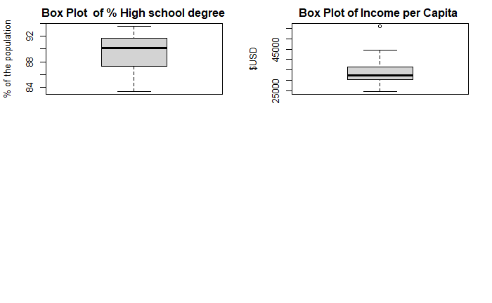

```r
merged_data$Population.2014.Population %>%
  boxplot(main = "Population in 2014",
          ylab = "Population 1000")
par(mfrow = c(2, 2))
```

[output not shown]

Using box plots we can scan for any outliers within the data. However this method is useful it only works on non-normal data, so it should be checked if the data is normally distributed.

```r
shapiro.test(merged_data$income.to.tuition.cost.ratio)
```

```
    Shapiro-Wilk normality test

data:  merged_data$income.to.tuition.cost.ratio
W = 0.91193, p-value = 0.001219
```

```r
shapiro.test(merged_data$`Avg tuition (USD)`)
```

```
    Shapiro-Wilk normality test

data:  merged_data$`Avg tuition (USD)`
W = 0.96341, p-value = 0.1236
```

```r
shapiro.test(merged_data$Income.Median.Houseold.Income)
```

```
    Shapiro-Wilk normality test

data:  merged_data$Income.Median.Houseold.Income
W = 0.95729, p-value = 0.06395
```

```r
shapiro.test(merged_data$Education.Bachelor.s.Degree.or.Higher)
```

```
    Shapiro-Wilk normality test

data:  merged_data$Education.Bachelor.s.Degree.or.Higher
W = 0.91122, p-value = 0.001019
```

```r
shapiro.test(merged_data$Education.High.School.or.Higher)
```

```
    Shapiro-Wilk normality test

data:  merged_data$Education.High.School.or.Higher
W = 0.94922, p-value = 0.02926
```

```r
shapiro.test(merged_data$Income.Per.Capita.Income)
```

```
    Shapiro-Wilk normality test

data:  merged_data$Income.Per.Capita.Income
W = 0.90822, p-value = 0.0008002
```

```r
shapiro.test(merged_data$Population.2014.Population)
```

```
    Shapiro-Wilk normality test

data:  merged_data$Population.2014.Population
W = 0.70994, p-value = 9.963e-09
```

Using the Shapiro Wilk test it can be seen that two of columns are normally distributed, as the p-value score is greater than 0.05 meaning that that the null hypothesis that the data is normally distributed is accepted. This means Tukeys method should not be used on average tuition and median household income as they are normally distributed.

With the columns that are not normally distributed, they will first be transformed to decrease the skweness and convert to a normal distribution and to get rid of any outliers.

```r
z.score<- merged_data$`Avg tuition (USD)`%>% scores(type = "z")
length(which(abs(z.score) >3 ))
```

```
[1] 0
```

```r
z.score1<- merged_data$Income.Median.Houseold.Income%>% scores(type = "z")
length(which(abs(z.score1) >3 ))
```

```
[1] 0
```

Here z scores have been used to detect outliers in the normally distributed data. A z score greater than 3 indicates an outlier but, here it can be seen that no outliers have been found.